# MPDW Pertemuan 5

Fedora Ilahi

2023-10-02

## Package yang digunakan

```r
library(ggplot2)
library(tsibble)
library(tseries)
library(MASS)
```

## Import data

```r
turisbali <- rio::import("https://raw.githubusercontent.com/ffddrraaa/tugas-mk-mpdw/main/Data/Data%20Pendatang%20Mancanegara%20di%20Provinsi%20Bali%202009-2020%20-%202009-2020.csv")
data.turis <- turisbali[,-c(1)]
data.turis
```

```
##        Bulan-Tahun Jumlah
## 1     January 2009 174541
## 2    February 2009 147704
## 3       March 2009 168205
## 4       April 2009 188776
## 5         May 2009 190803
## 6        June 2009 200566
## 7        July 2009 235198
## 8      August 2009 232255
## 9   September 2009 218443
## 10    October 2009 221282
## 11   November 2009 184803
## 12   December 2009 222546
## 13    January 2010 179273
## 14   February 2010 191926
```

[output cut: 119 more lines]

## Plot Time Series

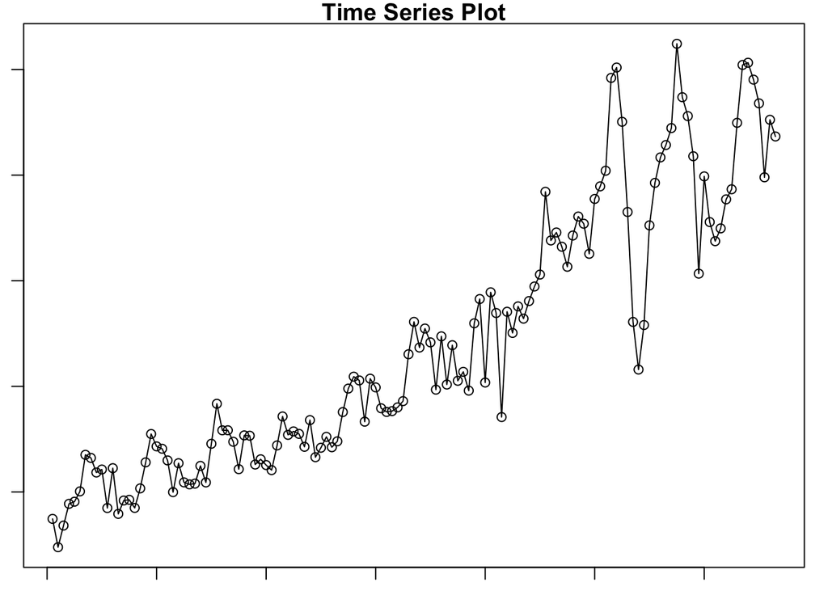

```r
data.ts <- ts(data.turis$Jumlah)
par(mar = c(1, 1, 1, 1))
ts.plot(data.ts, xlab="Periode", ylab="Wisatawan",
        main = "Time Series Plot")
points(data.ts)
```

```r
mean(data.turis$Jumlah)
```

```
## [1] 340544
```

Plot time series di atas menunjukkan bahwa data tidak stasioner dalam rataan, dibuktikan dengan data yang tidak menyebar di sekitar nilai tengahnya dan tidak stasioner dalam ragam, ditandai dengan lebar pita yang cenderung berbeda. Data pengunjung turis wisatawan cenderung musiman dan tidak stasioner

### Plot ACF

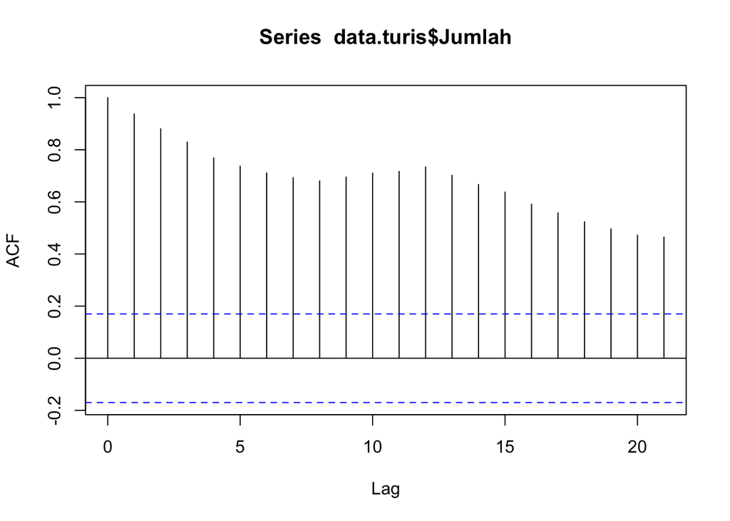

```r
acf(data.turis$Jumlah)
```

Berdasarkan plot ACF, terlihat bahwa plot ACF pada data tersebut cenderung *tails off* yang menandakan bahwa data tidak stasioner

### Uji ADF

```r
tseries::adf.test(data.turis$Jumlah)
```

```
##
##  Augmented Dickey-Fuller Test
##
## data:  data.turis$Jumlah
## Dickey-Fuller = -3.9099, Lag order = 5, p-value = 0.01582
## alternative hypothesis: stationary
```

$H_0$ : Data tidak stasioner dalam rataan

$H_1$ : Data stasioner dalam rataan

Berdasarkan uji ADF tersebut, didapat *p-value* sebesar 0.01582 yang lebih kecil dari taraf nyata 5% sehingga tolak $H_0$ dan menandakan bahwa data stasioner dalam rataan. Hal ini tidak sesuai dengan hasil eksplorasi menggunakan plot time series dan plot ACF. Jika menggunakan hasil ekplorasi menandakan data tidak stasioner dalam rataan justru berpola trend

Sehingga, dilakukan diferensiasi. Diferensiasi yang pertama adalah diferensiasi guna menghilangkan efek musiman pada data yang menyebabkan data menjadi tidak stasioner.

```r
AP.dslog1=diff(log(data.turis$Jumlah),differences=1,lag=25)
adf.test(AP.dslog1)
```

```
##
##  Augmented Dickey-Fuller Test
##
## data:  AP.dslog1
## Dickey-Fuller = -3.6455, Lag order = 4, p-value = 0.03241
## alternative hypothesis: stationary
```

$H_0$ : Data tidak stasioner dalam rataan

$H_1$ : Data stasioner dalam rataan

Berdasarkan uji ADF tersebut, didapat *p-value* sebesar 0.03241 yang kurang dari taraf nyata 5% sehingga tolak $H_0$ sehingga data stasioner dalam rataan. Hal ini belum sesuai dengan hasil eksplorasi menggunakan plot time series dan plot ACF. Kemudian dilakukan diferensiasi kedua kembali guna menghilangkan efek musiman

```r
AP.dslog2=diff(log(data.turis$Jumlah),differences=2,lag=25)
adf.test(AP.dslog2)
```

```
##
##  Augmented Dickey-Fuller Test
##
## data:  AP.dslog2
## Dickey-Fuller = -2.6845, Lag order = 4, p-value = 0.2952
## alternative hypothesis: stationary
```

Berdasarkan uji ADF dengan diferensiasi kedua tersebut, didapat *p-value* sebesar 0.2952 yang lebih besar dari taraf nyata 5% sehingga terima $H_0$ dan menandakan bahwa data tidak stasioner dalam rataan. Hal ini sesuai dengan hasil eksplorasi menggunakan plot time series dan plot ACF.

### Plot Box-Cox

```r
index <- seq(1:133)
bc = boxcox(data.turis$Jumlah~index, lambda = seq(-6, 6, by=0.01))
```

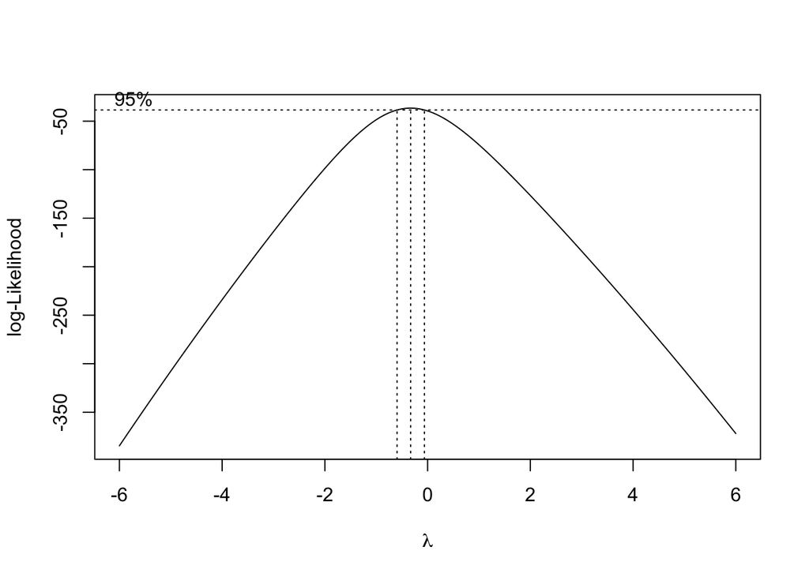

```r
#Nilai Rounded Lambda
lambda <- bc$x[which.max(bc$y)]
lambda
```

```
## [1] -0.33
```

```r
#SK
bc$x[bc$y > max(bc$y) - 1/2 * qchisq(.95,1)]
```

```
##  [1] -0.59 -0.58 -0.57 -0.56 -0.55 -0.54 -0.53 -0.52 -0.51 -0.50 -0.49 -0.48
## [13] -0.47 -0.46 -0.45 -0.44 -0.43 -0.42 -0.41 -0.40 -0.39 -0.38 -0.37 -0.36
## [25] -0.35 -0.34 -0.33 -0.32 -0.31 -0.30 -0.29 -0.28 -0.27 -0.26 -0.25 -0.24
## [37] -0.23 -0.22 -0.21 -0.20 -0.19 -0.18 -0.17 -0.16 -0.15 -0.14 -0.13 -0.12
## [49] -0.11 -0.10 -0.09 -0.08 -0.07
```

Gambar di atas menunjukkan nilai *rounded value* ($\lambda$) optimum sebesar **-0.33** dan pada selang kepercayaan 95% nilai memiliki batas bawah **-0.59** dan batas atas **-0.07**. Selang tersebut tidak memuat nilai satu sehingga dapat dikatakan bahwa data tidak stasioner dalam ragam.

## Partisi Data Bagian 1

```r
dt_stas1 <- data.turis$Jumlah[1:70] |> ts()
mean(dt_stas1)
```

```
## [1] 244832.8
```

```r
var(dt_stas1)
```

```
## [1] 2019418045
```

### Plot Time Series

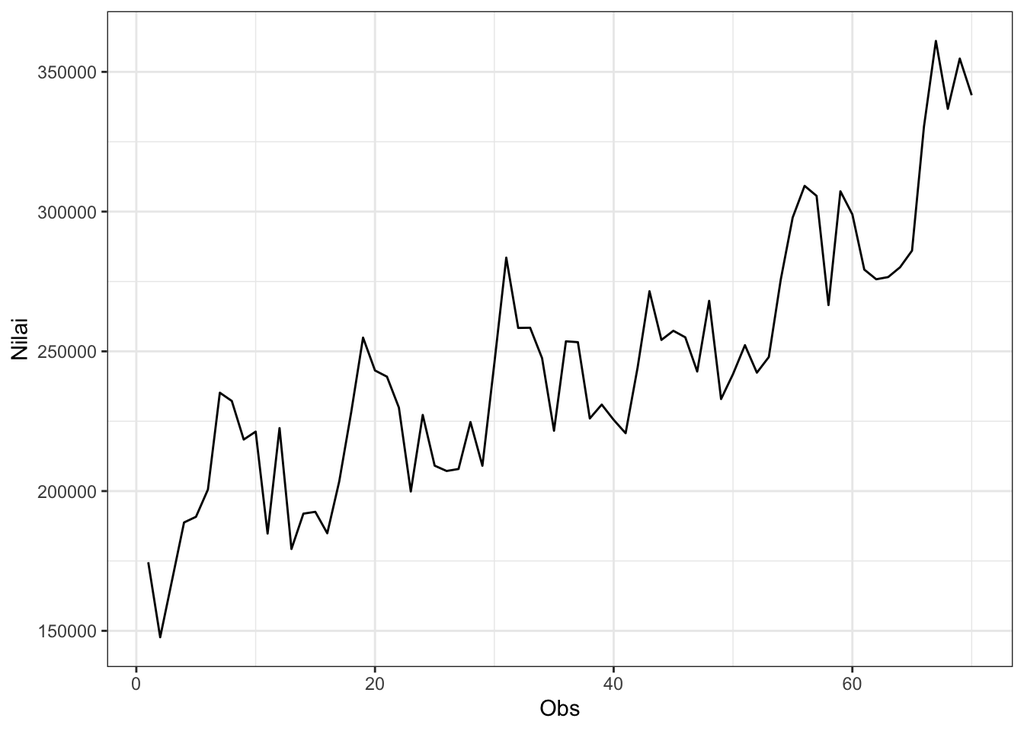

```r
dt_stas1 |> as_tsibble() |>
  ggplot(aes(x = index, y = value)) +
  geom_line() + theme_bw() +
  xlab("Obs") + ylab("Nilai")
```

Kembali lagi, plot deret waktu tersebut menunjukkan bahwa data tidak stasioner dalam rataan yang ditandai dengan data yang tidak menyebar di sekitar nilai tengahnya dan tidak stasioner dalam ragam dan ditandai dengan lebar pita yang cenderung berbeda.

### Plot ACF

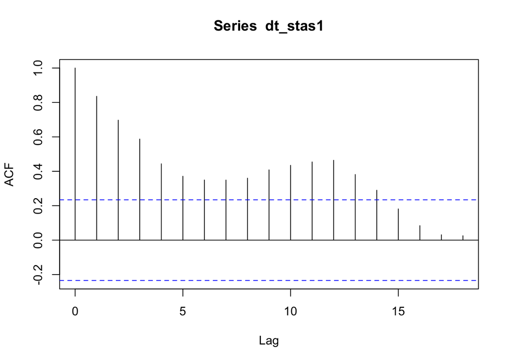

```r
acf(dt_stas1)
```

Berdasarkan plot ACF, terlihat bahwa plot ACF pada data tersebut cenderung *tails off* slowly dan membentuk gelombang cosinus.

### Uji ADF

```r
tseries::adf.test(dt_stas1)
```

```
##
##  Augmented Dickey-Fuller Test
##
## data:  dt_stas1
## Dickey-Fuller = -3.9371, Lag order = 4, p-value = 0.01766
## alternative hypothesis: stationary
```

$H_0$ : Data tidak stasioner dalam rataan

$H_1$ : Data stasioner dalam rataan

Berdasarkan uji ADF tersebut, didapat *p-value* sebesar 0.01766 yang lebih kecil dari taraf nyata 5% sehingga tolak $H_0$ dan menandakan bahwa data stasioner dalam rataan. Hal ini tidak sesuai dengan hasil eksplorasi menggunakan plot time series dan plot ACF. Jika menggunakan hasil eksplorasi menandakan data tidak stasioner dalam rataan karena data trend.

Sehingga, dilakukan kembali diferensiasi. Diferensiasi yang pertama adalah diferensiasi guna menghilangkan efek musiman pada data yang menyebabkan data menjadi tidak stasioner.

```r
AP.dslog1=diff(log(dt_stas1),differences=1,lag=25)
adf.test(AP.dslog1)
```

```
##
##  Augmented Dickey-Fuller Test
##
## data:  AP.dslog1
## Dickey-Fuller = -2.4185, Lag order = 3, p-value = 0.4079
## alternative hypothesis: stationary
```

### Plot Box-Cox

```r
index <- seq(1:70)
bc = boxcox(dt_stas1~index, lambda = seq(-6, 8, by=0.01))
```

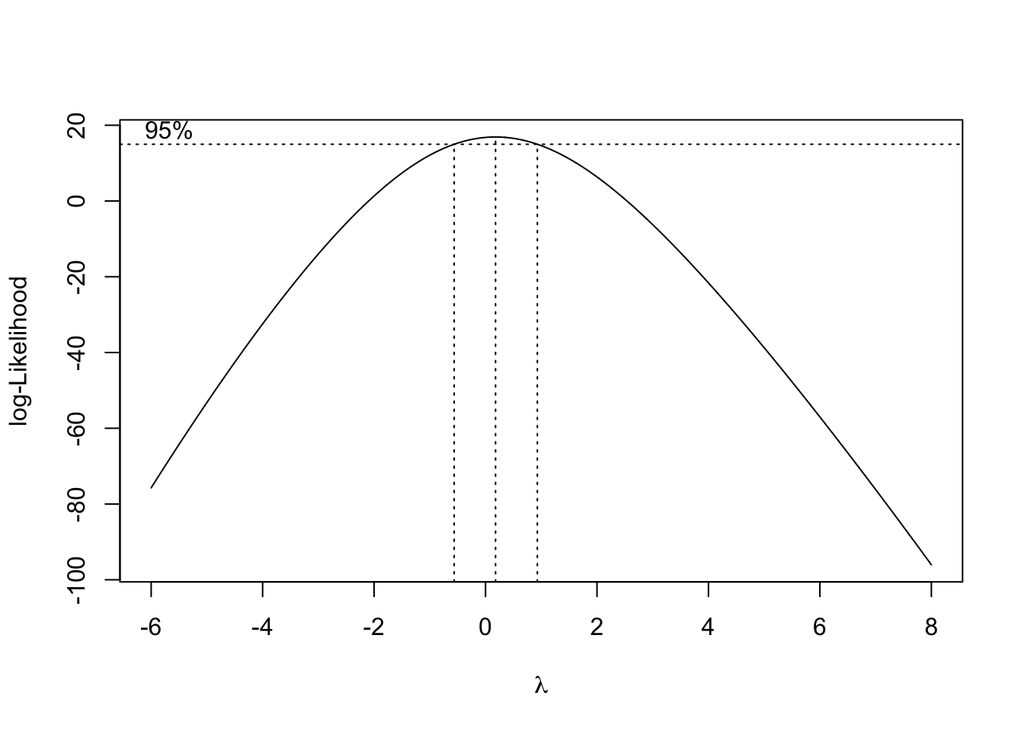

```r
#Nilai Rounded Lambda
lambda <- bc$x[which.max(bc$y)]
lambda
```

```
## [1] 0.18
```

```r
#SK
bc$x[bc$y > max(bc$y) - 1/2 * qchisq(.95,1)]
```

```
##   [1] -0.56 -0.55 -0.54 -0.53 -0.52 -0.51 -0.50 -0.49 -0.48 -0.47 -0.46 -0.45
##  [13] -0.44 -0.43 -0.42 -0.41 -0.40 -0.39 -0.38 -0.37 -0.36 -0.35 -0.34 -0.33
##  [25] -0.32 -0.31 -0.30 -0.29 -0.28 -0.27 -0.26 -0.25 -0.24 -0.23 -0.22 -0.21
##  [37] -0.20 -0.19 -0.18 -0.17 -0.16 -0.15 -0.14 -0.13 -0.12 -0.11 -0.10 -0.09
##  [49] -0.08 -0.07 -0.06 -0.05 -0.04 -0.03 -0.02 -0.01  0.00  0.01  0.02  0.03
##  [61]  0.04  0.05  0.06  0.07  0.08  0.09  0.10  0.11  0.12  0.13  0.14  0.15
##  [73]  0.16  0.17  0.18  0.19  0.20  0.21  0.22  0.23  0.24  0.25  0.26  0.27
##  [85]  0.28  0.29  0.30  0.31  0.32  0.33  0.34  0.35  0.36  0.37  0.38  0.39
##  [97]  0.40  0.41  0.42  0.43  0.44  0.45  0.46  0.47  0.48  0.49  0.50  0.51
## [109]  0.52  0.53  0.54  0.55  0.56  0.57  0.58  0.59  0.60  0.61  0.62  0.63
## [121]  0.64  0.65  0.66  0.67  0.68  0.69  0.70  0.71  0.72  0.73  0.74  0.75
## [133]  0.76  0.77  0.78  0.79  0.80  0.81  0.82  0.83  0.84  0.85  0.86  0.87
## [145]  0.88  0.89  0.90  0.91  0.92
```

Gambar di atas menunjukkan nilai *rounded value* ($\lambda$) optimum sebesar **0.18** dan pada selang kepercayaan 95% nilai memiliki batas bawah **-0.56** dan batas atas **0.92**. Selang tersebut tidak memuat nilai satu sehingga dapat dikatakan bahwa data wisatawan tidak stasioner dalam ragam.

## Partisi Data Bagian 2

```r
dt_stas2 <- data.turis$Jumlah[1:40] |> ts()
mean(dt_stas2)
```

```
## [1] 218092.4
```

```r
var(dt_stas2)
```

```
## [1] 835543173
```

### Plot Time Series

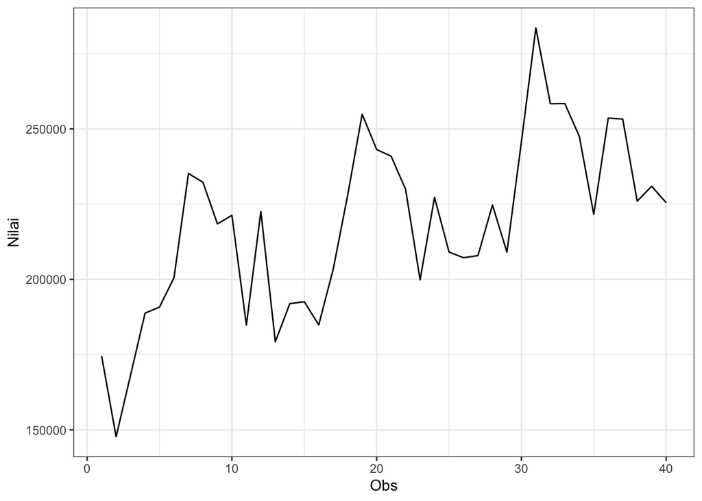

```r
dt_stas2 |> as_tsibble() |>
  ggplot(aes(x = index, y = value)) +
  geom_line() + theme_bw() +
  xlab("Obs") + ylab("Nilai")
```

### Plot ACF

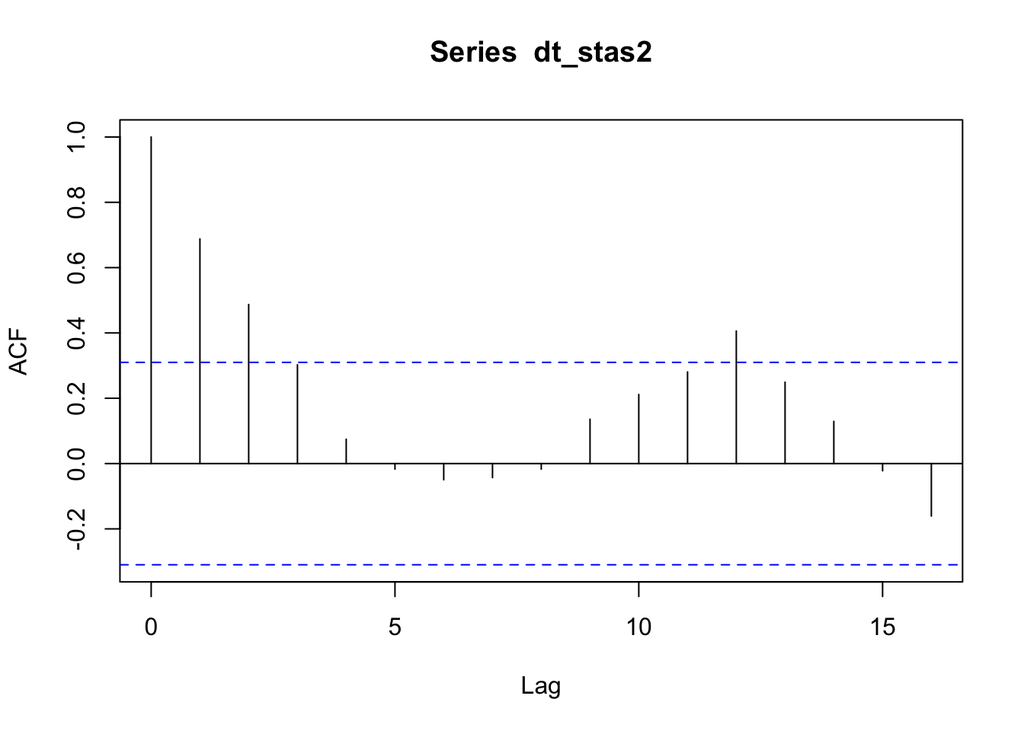

```r
acf(dt_stas2)
```

### Uji ADF

```r
tseries::adf.test(dt_stas2)
```

```
##
##  Augmented Dickey-Fuller Test
##
## data:  dt_stas2
## Dickey-Fuller = -3.9766, Lag order = 3, p-value = 0.02069
## alternative hypothesis: stationary
```

$H_0$ : Data tidak stasioner dalam rataan

$H_1$ : Data stasioner dalam rataan

Berdasarkan uji ADF tersebut, didapat *p-value* sebesar 0.02069 yang lebih kecil dari taraf nyata 5% sehingga tolak $H_0$ dan menandakan bahwa data stasioner dalam rataan. Hal ini tidak sesuai dengan hasil eksplorasi menggunakan plot time series dan plot ACF. Jika menggunakan hasil eksplorasi menandakan data tidak stasioner dalam rataan karena data trend.

Sehingga, dilakukan kembali diferensiasi. Diferensiasi yang pertama adalah diferensiasi guna menghilangkan efek musiman pada data yang menyebabkan data menjadi tidak stasioner.

```r
AP.dslog2=diff(log(dt_stas2),differences=1,lag=25)
adf.test(AP.dslog2)
```

```
##
##  Augmented Dickey-Fuller Test
##
## data:  AP.dslog2
## Dickey-Fuller = -1.6138, Lag order = 2, p-value = 0.7195
## alternative hypothesis: stationary
```

### Plot Box-Cox

```r
index <- seq(1:40)
bc = boxcox(dt_stas2~index, lambda = seq(-6, 10, by=0.01))
```

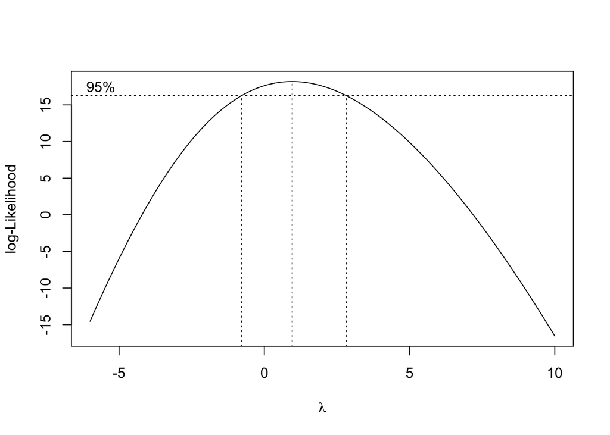

```r
#Nilai Rounded Lambda
lambda <- bc$x[which.max(bc$y)]
lambda
```

```
## [1] 0.96
```

```r
#SK
bc$x[bc$y > max(bc$y) - 1/2 * qchisq(.95,1)]
```

```
##   [1] -0.77 -0.76 -0.75 -0.74 -0.73 -0.72 -0.71 -0.70 -0.69 -0.68 -0.67 -0.66
##  [13] -0.65 -0.64 -0.63 -0.62 -0.61 -0.60 -0.59 -0.58 -0.57 -0.56 -0.55 -0.54
##  [25] -0.53 -0.52 -0.51 -0.50 -0.49 -0.48 -0.47 -0.46 -0.45 -0.44 -0.43 -0.42
##  [37] -0.41 -0.40 -0.39 -0.38 -0.37 -0.36 -0.35 -0.34 -0.33 -0.32 -0.31 -0.30
##  [49] -0.29 -0.28 -0.27 -0.26 -0.25 -0.24 -0.23 -0.22 -0.21 -0.20 -0.19 -0.18
##  [61] -0.17 -0.16 -0.15 -0.14 -0.13 -0.12 -0.11 -0.10 -0.09 -0.08 -0.07 -0.06
##  [73] -0.05 -0.04 -0.03 -0.02 -0.01  0.00  0.01  0.02  0.03  0.04  0.05  0.06
##  [85]  0.07  0.08  0.09  0.10  0.11  0.12  0.13  0.14  0.15  0.16  0.17  0.18
##  [97]  0.19  0.20  0.21  0.22  0.23  0.24  0.25  0.26  0.27  0.28  0.29  0.30
## [109]  0.31  0.32  0.33  0.34  0.35  0.36  0.37  0.38  0.39  0.40  0.41  0.42
## [121]  0.43  0.44  0.45  0.46  0.47  0.48  0.49  0.50  0.51  0.52  0.53  0.54
## [133]  0.55  0.56  0.57  0.58  0.59  0.60  0.61  0.62  0.63  0.64  0.65  0.66
## [145]  0.67  0.68  0.69  0.70  0.71  0.72  0.73  0.74  0.75  0.76  0.77  0.78
## [157]  0.79  0.80  0.81  0.82  0.83  0.84  0.85  0.86  0.87  0.88  0.89  0.90
## [169]  0.91  0.92  0.93  0.94  0.95  0.96  0.97  0.98  0.99  1.00  1.01  1.02
## [181]  1.03  1.04  1.05  1.06  1.07  1.08  1.09  1.10  1.11  1.12  1.13  1.14
## [193]  1.15  1.16  1.17  1.18  1.19  1.20  1.21  1.22  1.23  1.24  1.25  1.26
## [205]  1.27  1.28  1.29  1.30  1.31  1.32  1.33  1.34  1.35  1.36  1.37  1.38
## [217]  1.39  1.40  1.41  1.42  1.43  1.44  1.45  1.46  1.47  1.48  1.49  1.50
## [229]  1.51  1.52  1.53  1.54  1.55  1.56  1.57  1.58  1.59  1.60  1.61  1.62
## [241]  1.63  1.64  1.65  1.66  1.67  1.68  1.69  1.70  1.71  1.72  1.73  1.74
## [253]  1.75  1.76  1.77  1.78  1.79  1.80  1.81  1.82  1.83  1.84  1.85  1.86
## [265]  1.87  1.88  1.89  1.90  1.91  1.92  1.93  1.94  1.95  1.96  1.97  1.98
## [277]  1.99  2.00  2.01  2.02  2.03  2.04  2.05  2.06  2.07  2.08  2.09  2.10
## [289]  2.11  2.12  2.13  2.14  2.15  2.16  2.17  2.18  2.19  2.20  2.21  2.22
## [301]  2.23  2.24  2.25  2.26  2.27  2.28  2.29  2.30  2.31  2.32  2.33  2.34
## [313]  2.35  2.36  2.37  2.38  2.39  2.40  2.41  2.42  2.43  2.44  2.45  2.46
## [325]  2.47  2.48  2.49  2.50  2.51  2.52  2.53  2.54  2.55  2.56  2.57  2.58
## [337]  2.59  2.60  2.61  2.62  2.63  2.64  2.65  2.66  2.67  2.68  2.69  2.70
## [349]  2.71  2.72  2.73  2.74  2.75  2.76  2.77  2.78  2.79  2.80  2.81
```

Gambar di atas menunjukkan nilai *rounded value* ($\lambda$) optimum sebesar **0.96** dan pada selang kepercayaan 95% nilai memiliki batas bawah **-0.77** dan batas atas **2.81**. Selang tersebut memuat nilai satu sehingga dapat dikatakan bahwa data wisatawan stasioner dalam ragam.